# **Ideological Analysis**

Through the analysis from the last tab, it has been known that some key terms’ frequency of appearance *does* change during and after movement events, and that the patterns of change are different for the 1986 Student Demonstration and the Tiananmen Square Protest in 1989. In this tab, we further analyze these differing patterns and seek to acheive a more accurate understanding of official discourses of authoritarian government in social movement cycles.

To track patterns of word frequency changes, we further group all terms in the People’s Daily into three subcategories, following a Weberian conceptual fashion. First, we create a subcategory named “strong ideology” (hereafter SI), containing all terms related to ideologies and counter-ideologies of socialism, including socialism, capitalism, proletariat, bourgeois liberalism, revolution etc. This subcategory broadly corresponds to traditional authority in Weberian terms; Second, a subcategory of “weak ideology” (hereafter WI) is also generated, including terms containing rationalist-legalist implications in Weberian sense. This subcategory contains words such as reform, stability, stability and unity, etc; Lastly, we generate a subcategory named “economic performance” (hereafter EP) and include in it those key terms relevant to economic performance, such as economy construction, prosperity, etc.

We then present two graphs depicting the percentages of terms in each subcategory in all reports on the front page of the People’s Daily. The first plots the trend on a monthly basis, while the second on a more detailed, daily basis *(Note: in both plots the blue and red dashed lines denote the periods of social movements in 1986 and 1989 respectively)*:

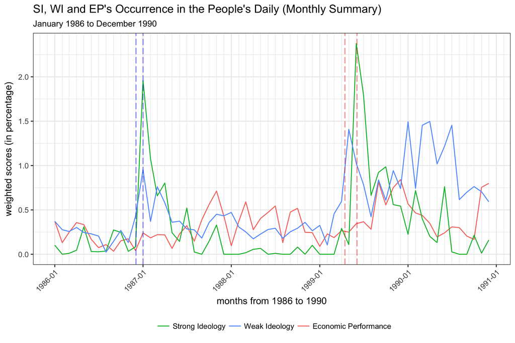

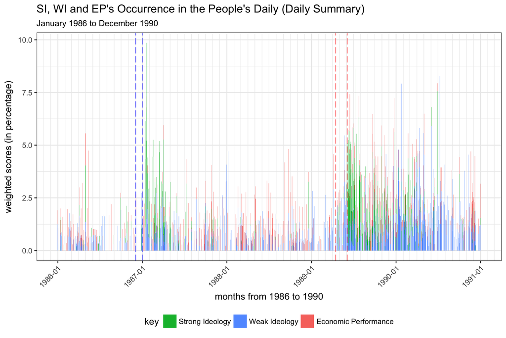